# Investigating the relationship between Retail Sales Activity in Australia, The Rate of Inflation & The Target Interest Rate.

Ryan Chand

2023-09-25

All raw data used in this case study was obtained via the Reserve Bank of Australia (RBA) refer to: [RBA Historical Data](https://www.rba.gov.au/statistics/historical-data.html)

This markdown file outlines the step-by-step process of obtaining, cleaning, transforming, visualising and performing statistical functions with the data for the purpose of the Google Data Analytics Professional Capstone Case Study Final Assessment.

Establishing baseline expectations for case study:

- We should expect to see a positive relationship between the rate of inflation and the target rate of interest, as higher inflation would lead to tighter monetary policy.
- We should expect to see an inverse relationship between retail sales activity and the rate of inflation, given that higher inflation outcomes lead to higher interest rates which have negative implications for household spending.

#### Step 1: Import CSVs from working directory and store within dataframe list

```r
  csv_directory <- "/Users/ryan/Documents/RStudio/Retail Sales Case Study"
  csv_files <- list.files(csv_directory, pattern = ".csv", full.names = TRUE)
  dataframes_list <- list()
```

Create a loop to read all the csv files stored in the csv files folder into the list

```r
for (csv_file in csv_files) {
  df <- read.csv(csv_file)
  dataframes_list[[csv_file]] <- df
}
```

Now that all CSV’s within the directory have been read into the list, store them separately as their own dataframes to clean them separately.

```r
df1 <- dataframes_list[[1]]
df2 <- dataframes_list[[2]]
df3 <- dataframes_list[[3]]
df4 <- dataframes_list[[4]]
```

#### Step 2 - Clean data

The first row in the CSVs contain descriptions of units and measurement frequencies. Replace this, and set the these to the column titles (currently in row 2) -> Use the colnames function to drop row 1.

```r
colnames(df1) <- df1[1,]
df1 <- df1[-1,]

colnames(df2) <- df2[1,]
df2 <- df2[-1,]

colnames(df3) <- df3[1,]
df3 <- df3[-1,]
```

Checking the new header row, DF3 does not have a title for the year column, use colnames function to input title in column 1 as follows:

```r
colnames(df3)[1] <- "Year"
```

Check the format of the Year column in each dataframe

```r
class(df1$Year)
class(df2$Year)
class(df3$Year)
class(df4$Year)
```

Currently each date column is stored as in character format, for statistical tests and visualization functions, these will need to be reformatted as dates. Additionally, to avoid issues in grouping data, append ‘15’ as the day for each of the dates (for consistency) in the columns when reformatting to DD-MM-YYYY:

```r
df1$Year <- as.Date(paste0("15-", df1$Year), format = "%d-%b-%Y")
df2$Year <- as.Date(paste0("15-", df2$Year), format = "%d-%b-%Y")
df3$Year <- as.Date(paste0("15-", df3$Year), format = "%d-%b-%Y")
df4$Year <- as.Date(paste0("15-", df4$Year), format = "%d-%b-%Y")
```

For the purpose of statistical testing, the year 2000 will be the cutoff for the historical data period for reasons of maintaining data that contains more relevant and recent economic policy regimes (i.e. assume for this test using RBA data from the 1980s would result in observations which include 18% interest rates and double digit inflation, which isn’t an accurate representation of the current macroeconomic environment).

Before creating a subset of the dataframes, they must be stored in a consistent date format as one of the following:

- “%Y-%m-%d”,
- “%d-%b-%Y”,
- “%d/%m/%Y”,
- “%m/%d/%Y”

To ensure every row within the Year column is stored in one of these formats, use a loop:

```r
date_formats <- c("%Y-%m-%d", "%d-%b-%Y", "%d/%m/%Y", "%m/%d/%Y")

# Create a vector to store each "successful format" instance
successful_format <- NULL

# Loop through the date formats and attempt to parse the dates
for (format in date_formats) {
  parsed_dates <- try(strptime(df1$Year, format), silent = TRUE)
  if (!inherits(parsed_dates, "try-error")) {
    successful_format <- format
    break
  }
}

# Print the successful date format
if (!is.null(successful_format)) { #any format that has passed the test, i.e. is not null
  cat("The current format in the 'Year' column is:", successful_format, "\n")
} else {
  cat("Unable to determine the format of the 'Year' column.\n") #for error "null" reads
}
```

```
## The current format in the 'Year' column is: %Y-%m-%d
```

The above loop confirms all rows are formatted correctly.

**Create the subset dataframes for the year 2000 onwards:**

Store DF1 (CPI data) into its own subset from row 313 onwards and clean column names which contain special characters (as these cannot be used in a group function or ggplot), and store the percentage change values as numeric so they can be summarised using mathematical functions:

```r
cpi_df1_test <- df1[313:nrow(df1), ] #The subset dataframe will contain data from rows 313 onwards

#Clean column names
colnames(cpi_df1_test)[4] <- "CPI chg Year End" #Renaming the columns which contain special characters
colnames(cpi_df1_test)[14] <- "CPI chg Quarterly"
cpi_df1_test$`CPI chg Year End` <- as.numeric(cpi_df1_test$`CPI chg Year End`) #CPI chg Year End cannot be summarised by mean in chr format, reformatted to numeric
```

Repeating the process for the other dataframes with the exception of DF2 lending data which only begins at 2019. For the purpose of the statistical test this dataframe will be excluded in order to maintain a consistent time series across the datasets.

```r
#Creating the subsets for DF3 and DF4
activity_indicators_df3 <- df3[422:nrow(df3),]
monetary_policy_data <- df4[368:nrow(df4),]

#Rename columns that currently contain special characters
colnames(activity_indicators_df3)[2] <- "retail_sales_allcurrent_industries_thsnds"
colnames(activity_indicators_df3)[4] <- "retail_sales_allcurrent_industries_yrend_pcntchg"
colnames(activity_indicators_df3)[5] <- "private_dwelling_approvals_thsnds"

#convert following columns to numeric in order to perform mathematical fucntions
activity_indicators_df3$retail_sales_allcurrent_industries_thsnds <- as.numeric(activity_indicators_df3$retail_sales_allcurrent_industries_thsnds)
activity_indicators_df3$retail_sales_allcurrent_industries_yrend_pcntchg <-as.numeric(activity_indicators_df3$retail_sales_allcurrent_industries_yrend_pcntchg)
activity_indicators_df3$private_dwelling_approvals_thsnds <- as.numeric(activity_indicators_df3$private_dwelling_approvals_thsnds)

colnames(monetary_policy_data)[2] <- "cashratetarget_monthlyavg"
colnames(monetary_policy_data)[14] <- "tnotes_1mthrate_monthlyavg"
colnames(monetary_policy_data)[15] <- "tnotes_3mthrate_monthlyavg"
colnames(monetary_policy_data)[16] <- "tnotes_6mthrate_monthlyavg"

monetary_policy_data$cashratetarget_monthlyavg <- as.numeric(monetary_policy_data$cashratetarget_monthlyavg)
monetary_policy_data$tnotes_1mthrate_monthlyavg <- as.numeric(monetary_policy_data$tnotes_1mthrate_monthlyavg)
monetary_policy_data$tnotes_3mthrate_monthlyavg <- as.numeric(monetary_policy_data$tnotes_3mthrate_monthlyavg)
monetary_policy_data$tnotes_6mthrate_monthlyavg <- as.numeric(monetary_policy_data$tnotes_6mthrate_monthlyavg)
```

```r
avg_cpi_df <- cpi_df1_test %>%
  mutate(Year = year(ymd(Year))) %>% #Informs current format as YMD and mutates
  group_by(`Year`) %>% #can then group by Year
  summarise(average_yearly_CPI = mean(`CPI chg Year End`, na.rm = TRUE)) #na.rm used to drop null values, summarising by average CPI for the year

monetary_policy_summary <- monetary_policy_data %>%
  mutate(Year = year(ymd(Year))) %>%
  group_by(`Year`) %>%
  summarise(average_cashratetarget = mean(`cashratetarget_monthlyavg`, na.rm = TRUE), average_1mtnoterate = mean(`tnotes_1mthrate_monthlyavg`, na.rm = TRUE), average_3mtnoterate = mean(`tnotes_3mthrate_monthlyavg`, na.rm = TRUE), average_6mtnoterate = mean(`tnotes_6mthrate_monthlyavg`, na.rm = TRUE))

retail_activity <- activity_indicators_df3 %>%
  mutate(Year = year(ymd(Year))) %>%
  group_by(`Year`) %>%
  summarise(average_retail_sales_allcurrent_industries_thsnds = mean(`retail_sales_allcurrent_industries_thsnds`, na.rm = TRUE), average_private_dwelling_approvals = mean(`private_dwelling_approvals_thsnds`, na.rm = TRUE), retailsales_yrendpcchange = mean(`retail_sales_allcurrent_industries_yrend_pcntchg`, na.rm = TRUE))
```

#### Step 3: Graph cleaned data

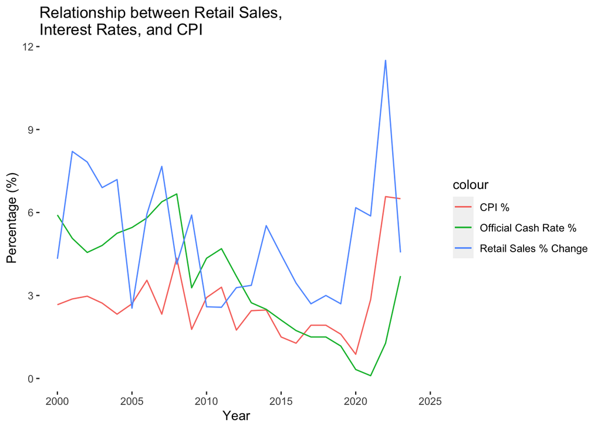

```r
ggplot() +
  geom_line(data = avg_cpi_df, mapping = aes(x = Year, y = average_yearly_CPI, color = 'CPI %')) +
  geom_line(data = monetary_policy_summary, mapping = aes(x = Year, y = average_cashratetarget, color = 'Official Cash Rate %')) +
  geom_line(data = retail_activity, mapping = aes(x = Year, y = retailsales_yrendpcchange, color = 'Retail Sales % Change')) +
  theme(
  plot.background = element_rect(fill = "white"),
  panel.background = element_rect(fill = "white"),
  panel.grid.major = element_blank(),
  panel.grid.minor = element_blank(),
  plot.title = element_text(color = "black"),      # Change title text color
    axis.title.x = element_text(color = "black"),   # Change x-axis label text color
    axis.title.y = element_text(color = "black")
  )+
  labs (title = "Relationship between Retail Sales, \nInterest Rates, and CPI", y = "Percentage (%)")
```

There is no clear relationship between retail sales activity and the other two variables, a multiple linear regression can be applied to check the statistical relationship.

#### Step 4: Statistical Test

Hypothesis Statement:

- H0: Percentage change in Retail Sales attributable to Inflation and Target Interest Rates is zero.
- Ha: Percentage change in Retail Sales attributable to Inflation and Target Interest Rates different to zero.

Before we can proceed, the dataframes will need to be merged by year (the common identifier) in order to get the primary variables in a single dataset, this is because the lm function used for the statistical test only accepts one data. Merging the data will require creating two new dataframes as the merge function only accepts two arguments in a single statement.

```r
total_economic_data <- merge(avg_cpi_df, retail_activity, by = "Year", all = TRUE)
combined_economic_data <- merge(total_economic_data, monetary_policy_summary, by = "Year", all=TRUE)
```

Next, use the lm function (stats package required) to run a multi regression with retail sales activity as the dependent variable.

```r
model <- lm(retailsales_yrendpcchange ~ average_cashratetarget + average_yearly_CPI , data = combined_economic_data)
summary(model)
```

```
##
## Call:
## lm(formula = retailsales_yrendpcchange ~ average_cashratetarget +
##     average_yearly_CPI, data = combined_economic_data)
##
## Residuals:
##    Min     1Q Median     3Q    Max
## -2.928 -1.774 -0.253  1.940  3.889
##
## Coefficients:
##                        Estimate Std. Error t value Pr(>|t|)
## (Intercept)             3.45328    1.20390   2.868   0.0092 **
## average_cashratetarget -0.03231    0.24036  -0.134   0.8943
## average_yearly_CPI      0.63863    0.34212   1.867   0.0760 .
## ---
## Signif. codes:  0 '***' 0.001 '**' 0.01 '*' 0.05 '.' 0.1 ' ' 1
##
## Residual standard error: 2.228 on 21 degrees of freedom
##   (1 observation deleted due to missingness)
## Multiple R-squared:  0.1455, Adjusted R-squared:  0.06407
## F-statistic: 1.787 on 2 and 21 DF,  p-value: 0.192
```

Based on the regression output, we cannot reject the null hypothesis due to the high p-value (exceeds both 5% and 10% levels of significant) and the low R-Squared values (implying a lack of correlation). Therefore, based on the current dataset there would be no statistically significant relationship between retail sales activity, inflation and interest rates.

- Drop one of the independent variables, and re-run the model.
- Standardization techniques, i.e. penalizing the addition of new independent variables added which have large coefficients.
- Principle Components Analysis (PCA) - Reduce dimensionality of data.

Given that this is a beginner level walkthrough, the first method is the simplest alternative, therefore, the model can be re-run using one of each of the independent variables:

```r
model <- lm(retailsales_yrendpcchange ~ average_yearly_CPI , data = combined_economic_data)
summary(model)
```

```
##
## Call:
## lm(formula = retailsales_yrendpcchange ~ average_yearly_CPI,
##     data = combined_economic_data)
##
## Residuals:
##     Min      1Q  Median      3Q     Max
## -2.8940 -1.7244 -0.2758  1.9292  4.0017
##
## Coefficients:
##                    Estimate Std. Error t value Pr(>|t|)
## (Intercept)          3.3684     1.0019   3.362  0.00281 **
## average_yearly_CPI   0.6281     0.3256   1.929  0.06668 .
## ---
## Signif. codes:  0 '***' 0.001 '**' 0.01 '*' 0.05 '.' 0.1 ' ' 1
##
## Residual standard error: 2.177 on 22 degrees of freedom
##   (1 observation deleted due to missingness)
## Multiple R-squared:  0.1447, Adjusted R-squared:  0.1058
## F-statistic: 3.722 on 1 and 22 DF,  p-value: 0.06668
```

```r
model <- lm(retailsales_yrendpcchange ~ average_cashratetarget , data = combined_economic_data)
summary(model)
```

```
##
## Call:
## lm(formula = retailsales_yrendpcchange ~ average_cashratetarget,
##     data = combined_economic_data)
##
## Residuals:
##     Min      1Q  Median      3Q     Max
## -2.6948 -1.8618 -0.5413  1.4014  6.5573
##
## Coefficients:
##                        Estimate Std. Error t value Pr(>|t|)
## (Intercept)             4.85339    0.99344   4.885 6.96e-05 ***
## average_cashratetarget  0.07019    0.24687   0.284    0.779
## ---
## Signif. codes:  0 '***' 0.001 '**' 0.01 '*' 0.05 '.' 0.1 ' ' 1
##
## Residual standard error: 2.35 on 22 degrees of freedom
##   (1 observation deleted due to missingness)
## Multiple R-squared:  0.003661,   Adjusted R-squared:  -0.04163
## F-statistic: 0.08084 on 1 and 22 DF,  p-value: 0.7788
```

No evidence for a statistically significant relationship.